### Week 5 Homework

### Auriel M.V. Fournier

```r
library(spdep)
library(rgdal)
library(sp)
data(columbus)

dat <- columbus

col <- readOGR(dsn='.', layer='columbus')
```

```
## with 49 features and 20 fields
## Feature type: wkbPolygon with 2 dimensions
```

```r
col.lm <- lm(CRIME ~ INC + HOVAL, data=columbus)
inc_hAIC <- AIC(col.lm)
summary(col.lm)
```

```
##
## Call:
## lm(formula = CRIME ~ INC + HOVAL, data = columbus)
##
## Residuals:
##     Min      1Q  Median      3Q     Max
## -34.418  -6.388  -1.580   9.052  28.649
##
## Coefficients:
##             Estimate Std. Error t value Pr(>|t|)
## (Intercept)  68.6190     4.7355  14.490  < 2e-16 ***
## INC          -1.5973     0.3341  -4.780 1.83e-05 ***
## HOVAL        -0.2739     0.1032  -2.654   0.0109 *
## ---
## Signif. codes:  0 '***' 0.001 '**' 0.01 '*' 0.05 '.' 0.1 ' ' 1
##
## Residual standard error: 11.43 on 46 degrees of freedom
## Multiple R-squared:  0.5524, Adjusted R-squared:  0.5329
## F-statistic: 28.39 on 2 and 46 DF,  p-value: 9.341e-09
```

I am choosing to look at Queen with binomial weights, Rook with row normalized weights and Rook with binomial weights. I choose two two schemes with binomial weights because I think there might be soem impact of the number of neighborhoods on the crime in a given neighborhood. I choose two with rook contigruity because neighborhoods that share sides may be more directly influenced then by those which share vertices. Though incorporating something related to roads might be more logical.

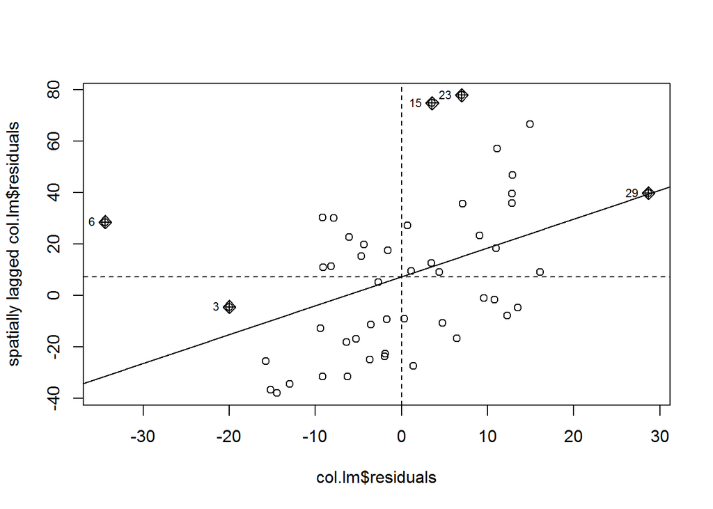

```r
col.qb <- nb2listw(poly2nb(col, queen=T),style="B")
col.rw <- nb2listw(poly2nb(col, queen=F),style="W")
col.rb <- nb2listw(poly2nb(col, queen=F),style="B")
moran.plot(col.lm$residuals, listw=col.qb)
```

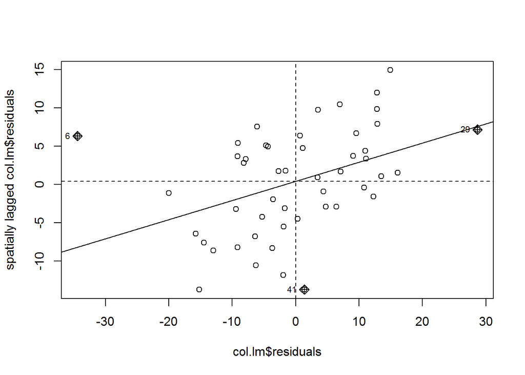

```r
moran.plot(col.lm$residuals, listw=col.rw)
```

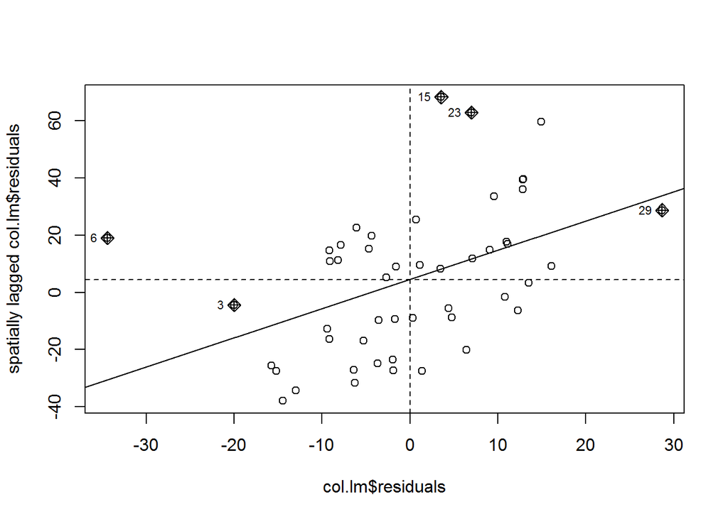

```r
moran.plot(col.lm$residuals, listw=col.rb)
```

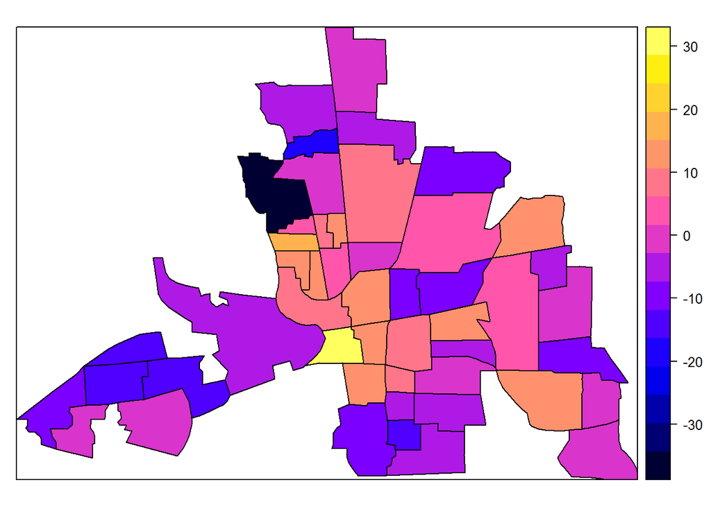

```r
col@data[,'residuals'] <- col.lm$residuals
spplot(col, zcol='residuals')
```

```r
qb <- lm.morantest(col.lm, col.qb, zero.policy=NULL, alternative="greater", spChk=NULL, resfun=weighted.residuals)
rw <- lm.morantest(col.lm, col.rw, zero.policy=NULL, alternative="greater", spChk=NULL, resfun=weighted.residuals)
rb <- lm.morantest(col.lm, col.rb, zero.policy=NULL, alternative="greater", spChk=NULL, resfun=weighted.residuals)
```

if we look at the relationship between INC and HOVAL we see that is positively related, as a result adding both to the lm() might be confounding. What if we just look at income level.

```r
data(columbus)

dat <- columbus

col <- readOGR(dsn='.', layer='columbus')
```

```
## with 49 features and 20 fields
## Feature type: wkbPolygon with 2 dimensions
```

```r
col.lm <- lm(CRIME ~ INC , data=columbus)
incAIC <- AIC(col.lm)

summary(col.lm)
```

```
##
## Call:
## lm(formula = CRIME ~ INC, data = columbus)
##
## Residuals:
##     Min      1Q  Median      3Q     Max
## -47.066  -6.663  -0.836   8.488  32.806
##
## Coefficients:
##             Estimate Std. Error t value Pr(>|t|)
## (Intercept)  64.4632     4.7480  13.577  < 2e-16 ***
## INC          -2.0407     0.3074  -6.638  2.9e-08 ***
## ---
## Signif. codes:  0 '***' 0.001 '**' 0.01 '*' 0.05 '.' 0.1 ' ' 1
##
## Residual standard error: 12.15 on 47 degrees of freedom
## Multiple R-squared:  0.4838, Adjusted R-squared:  0.4729
## F-statistic: 44.06 on 1 and 47 DF,  p-value: 2.901e-08
```

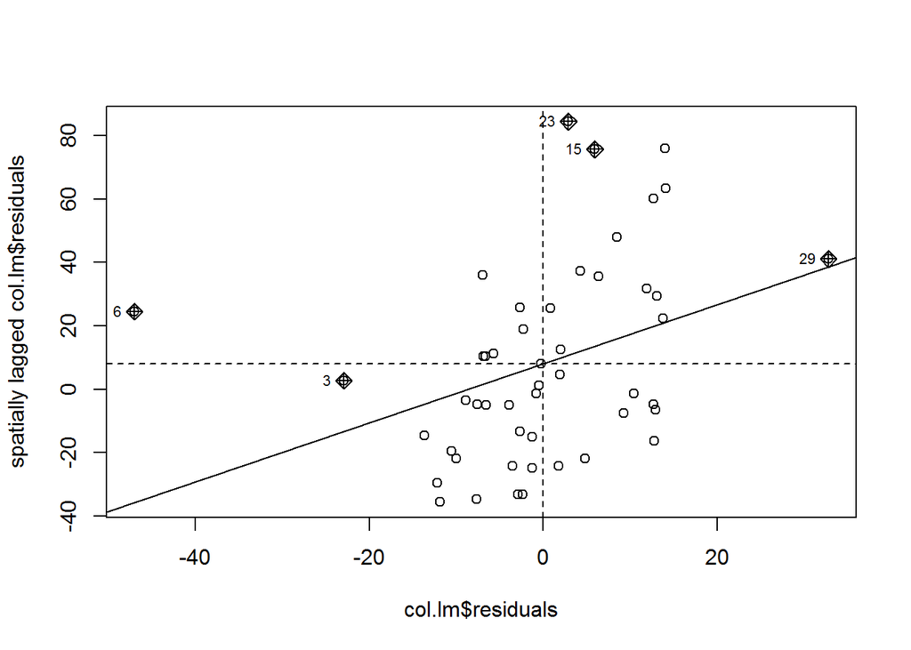

```r
col.qb <- nb2listw(poly2nb(col, queen=T),style="B")
col.rw <- nb2listw(poly2nb(col, queen=F),style="W")
col.rb <- nb2listw(poly2nb(col, queen=F),style="B")
moran.plot(col.lm$residuals, listw=col.qb)
```

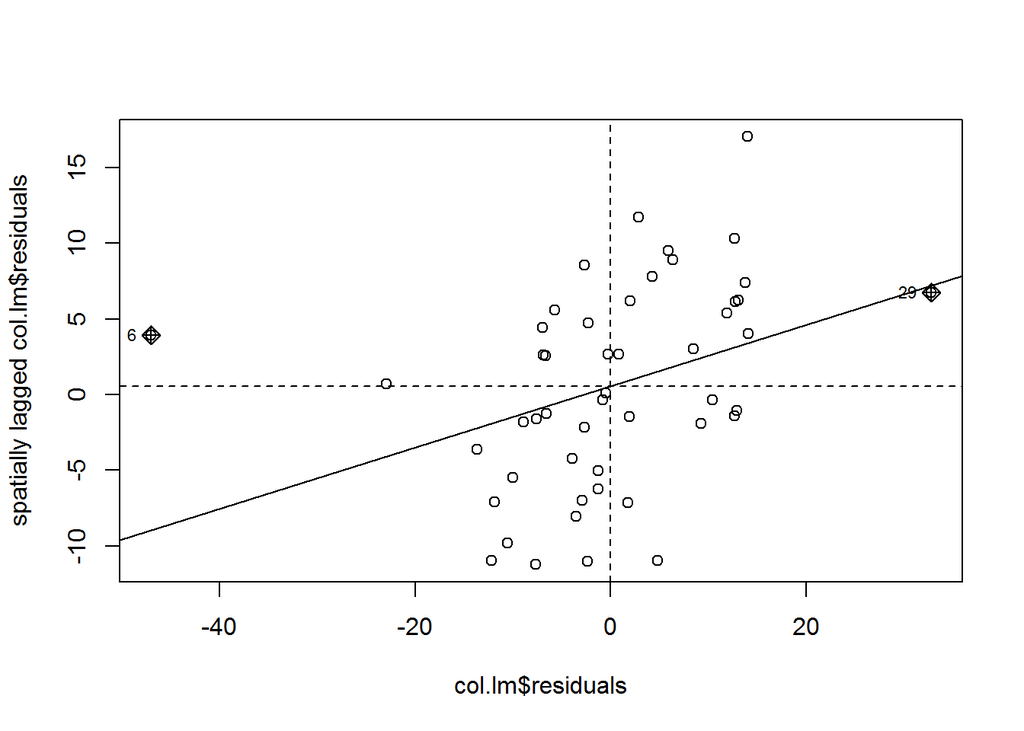

```r
moran.plot(col.lm$residuals, listw=col.rw)
```

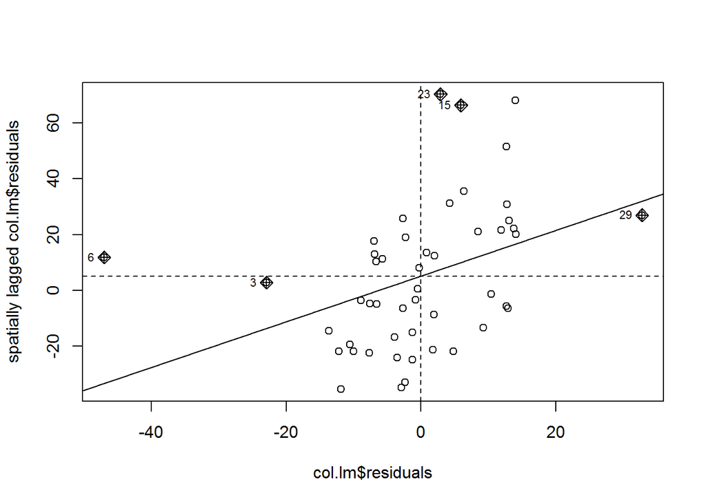

```r
moran.plot(col.lm$residuals, listw=col.rb)
```

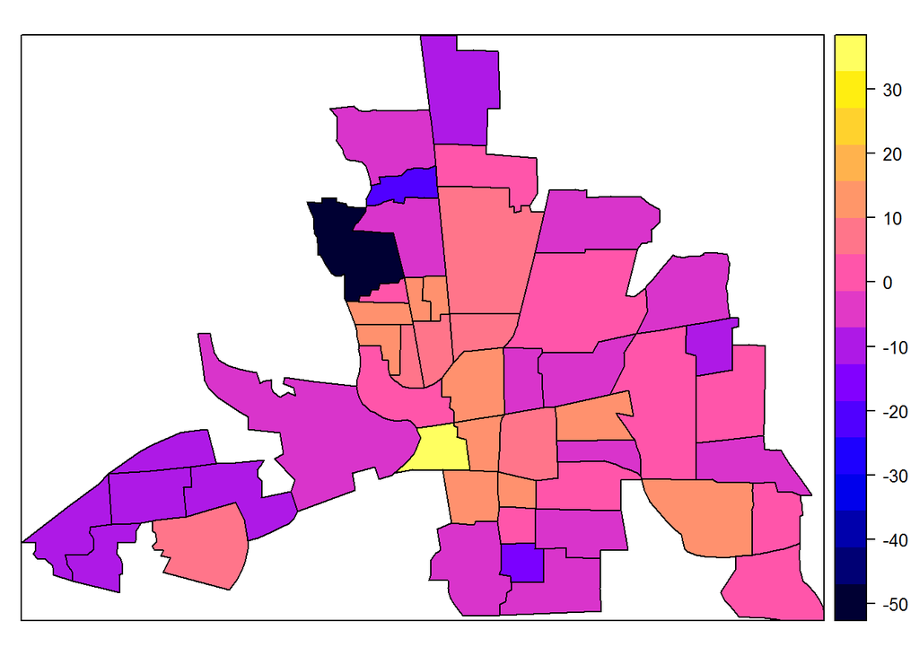

```r
col@data[,'residuals'] <- col.lm$residuals
spplot(col, zcol='residuals')
```

```r
qb <- lm.morantest(col.lm, col.qb, zero.policy=NULL, alternative="greater", spChk=NULL, resfun=weighted.residuals)
rw <- lm.morantest(col.lm, col.rw, zero.policy=NULL, alternative="greater", spChk=NULL, resfun=weighted.residuals)
rb <- lm.morantest(col.lm, col.rb, zero.policy=NULL, alternative="greater", spChk=NULL, resfun=weighted.residuals)
```

```r
data(columbus)

dat <- columbus

col <- readOGR(dsn='.', layer='columbus')
```

```
## with 49 features and 20 fields
## Feature type: wkbPolygon with 2 dimensions
```

```r
col.lm <- lm(CRIME ~ INC + HOVAL + PLUMB , data=columbus)
inc_h_pAIC <- AIC(col.lm)
summary(col.lm)
```

```
##
## Call:
## lm(formula = CRIME ~ INC + HOVAL + PLUMB, data = columbus)
##
## Residuals:
##     Min      1Q  Median      3Q     Max
## -31.201  -6.616  -0.478   7.578  18.524
##
## Coefficients:
##             Estimate Std. Error t value Pr(>|t|)
## (Intercept) 62.68463    4.63170  13.534  < 2e-16 ***
## INC         -1.29687    0.31506  -4.116 0.000162 ***
## HOVAL       -0.31454    0.09408  -3.343 0.001675 **
## PLUMB        1.34373    0.40014   3.358 0.001605 **
## ---
## Signif. codes:  0 '***' 0.001 '**' 0.01 '*' 0.05 '.' 0.1 ' ' 1
##
## Residual standard error: 10.34 on 45 degrees of freedom
## Multiple R-squared:  0.6421, Adjusted R-squared:  0.6182
## F-statistic: 26.91 on 3 and 45 DF,  p-value: 4.021e-10
```

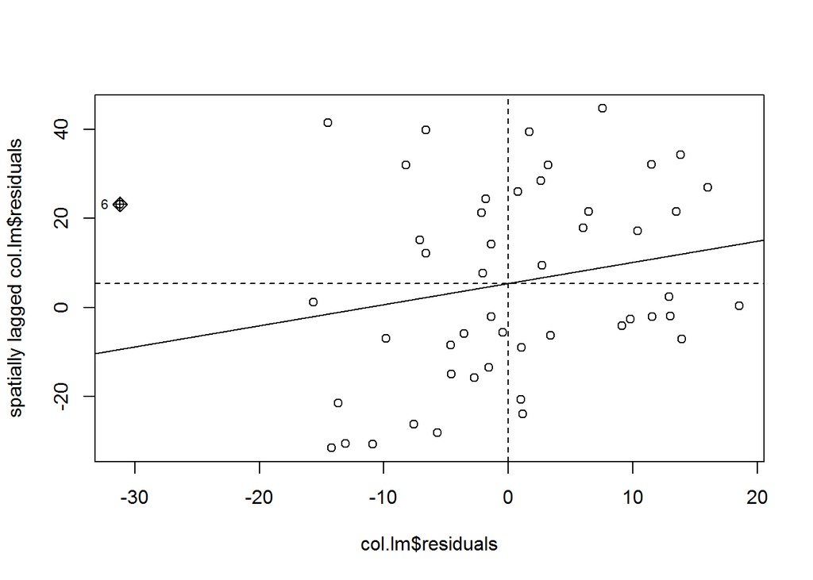

```r
col.qb <- nb2listw(poly2nb(col, queen=T),style="B")
col.rw <- nb2listw(poly2nb(col, queen=F),style="W")
col.rb <- nb2listw(poly2nb(col, queen=F),style="B")
moran.plot(col.lm$residuals, listw=col.qb)
```

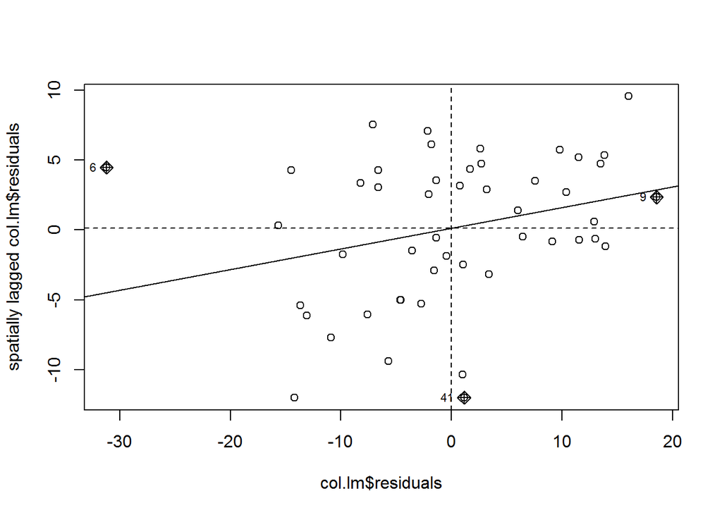

```r
moran.plot(col.lm$residuals, listw=col.rw)
```

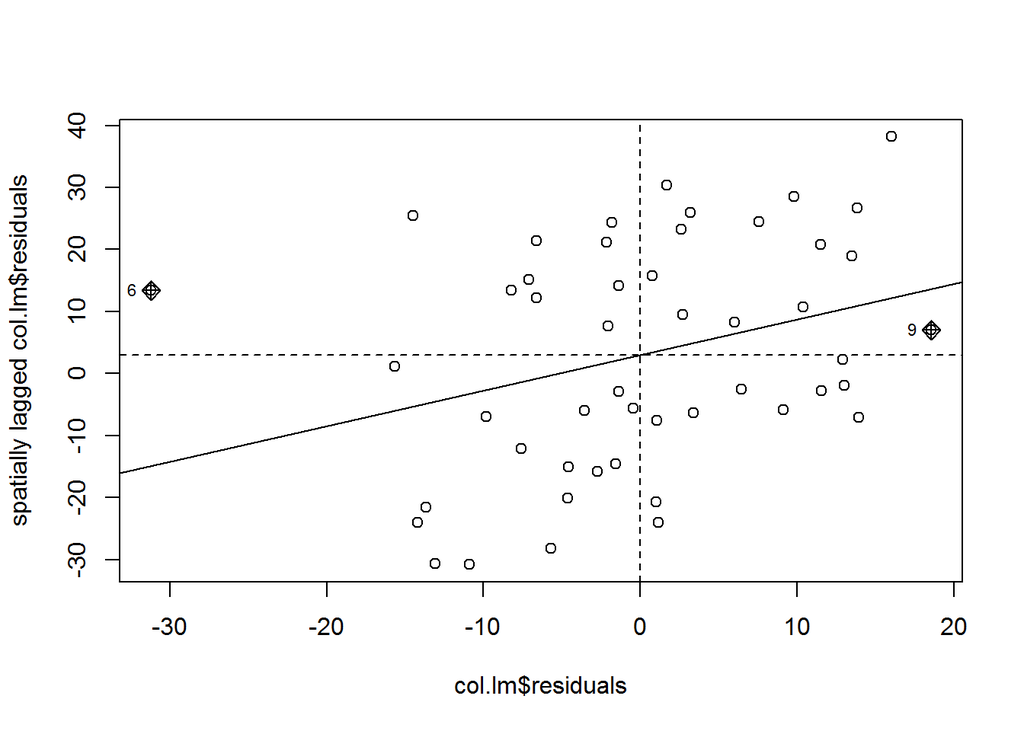

```r
moran.plot(col.lm$residuals, listw=col.rb)
```

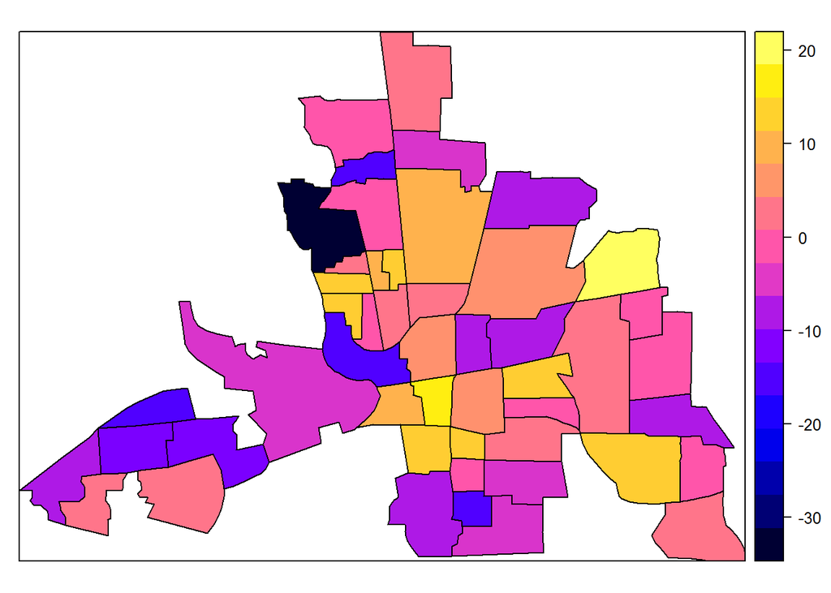

```r
col@data[,'residuals'] <- col.lm$residuals
spplot(col, zcol='residuals')
```

```r
qb <- lm.morantest(col.lm, col.qb, zero.policy=NULL, alternative="greater", spChk=NULL, resfun=weighted.residuals)
rw <- lm.morantest(col.lm, col.rw, zero.policy=NULL, alternative="greater", spChk=NULL, resfun=weighted.residuals)
rb <- lm.morantest(col.lm, col.rb, zero.policy=NULL, alternative="greater", spChk=NULL, resfun=weighted.residuals)
```

```r
incAIC
```

```
## [1] 387.7378
```

```r
inc_h_pAIC
```

```
## [1] 373.797
```

```r
inc_hAIC
```

```
## [1] 382.7545
```